# act_report

## Act_Report

By Joseph Osuntoki

## Introduction

[figure not shown]

```python
from PIL import Image
myImage = Image.open("wrd_profile.PNG");
myImage
```

WeRateDogs is a Twitter account that rates users' dogs and adds a lighthearted comment. The denominator of these scores is almost always 10. however, the numerators are frequently more than 10. e.g. 11/10, 12/10, 13/10, etc.

What are we to do with this data? Which dog is the most popular, the most loved? Can we find a connection between favorites, ratings, and tweets? In order to get the answers to these questions, I combed through the WeRateDogs twitter data and conducted an analysis. I was able to create some beautiful visualizations for my study with the aid of Python utilities.

I analyzed the data and came up with some valuable insights:

1. Only 937 dogs out of 1477 predicted dogs, were predicted with confidence greater than 50%. In second and third predictions, no dog was predicted with confidence greater than 50%
2. The most favorite and most popular dog classes are doggo and pupper with a combined score of over 80%
3. Golden_retriever, Labrador_retriever, and Pembroke are the most popular and favorite dog breeds
4. There is a very strong positive corelation between favorite_count and retweet_count with about 0.93 correlation score

The data was also visualized using the seaborn and matplotlib libraries.

## Most Popular Dog Breeds

The data was analyzed on first predictions with prediction confidence greater than 50%. The top 10 most popular dog breeds are:

1. Golden_retriever
2. Labrador_retriever
3. Pembroke
4. Chihuahua
5. Samoyed
6. French_bulldog
7. Chow
8. Pomeranian
9. Pug
10. Toy_poodle

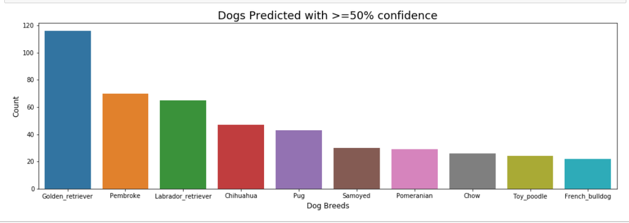

```python
ins = Image.open("Ins_1.PNG");
ins
```

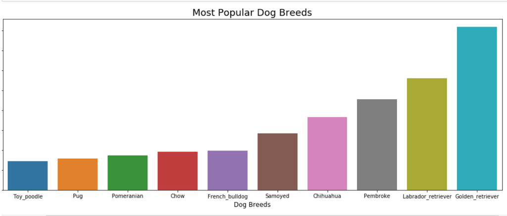

```python
ins = Image.open("Ins_2.PNG");
ins
```

## Most Favorite Dog Breed

The data was analyzed on first predictions with prediction confidence greater than 50%. The top 10 favorite dog breeds are:

1. Golden_retriever
2. Labrador_retriever
3. Pembroke
4. Chihuahua
5. Samoyed
6. French_bulldog
7. Chow
8. Pug
9. Pomeranian
10. Toy_poodle

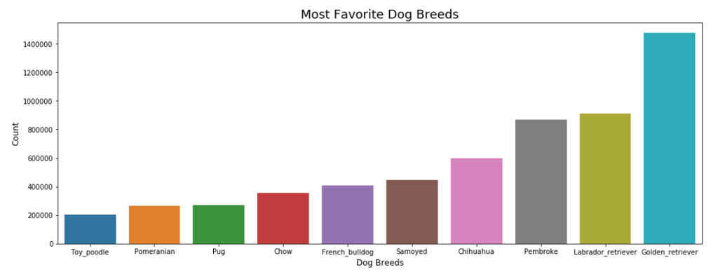

```python
ins = Image.open("Ins_3.PNG");
ins
```

#### Here's an image of our top dog_breed: "Golden_Retriever"

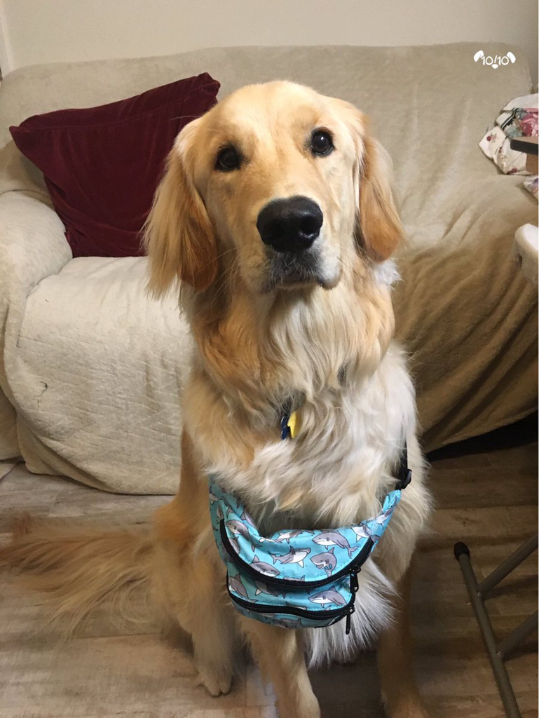

```python
import requests
from PIL import Image
from io import BytesIO

#Getting the Image of top rated Golden Retriever
url = 'https://pbs.twimg.com/media/DFg_2PVW0AEHN3p.jpg'
response = requests.get(url)
Image.open(BytesIO(response.content))
```

## Relationship between favorite count, retweet count and rating numerator

It was discovered there is a very strong positive corelation between favorite_count and retweet_count with about 0.93 correlation score. However, there is a weak relationship between rating and retweet_count or favorite_count.

The analysis is demonstrated in the visuals below (A heatmap, scatter matrix, and reg plot). And it shows the strength of the relationship between the variables considered (favorite_count, retweet_count, and rating_numerator)

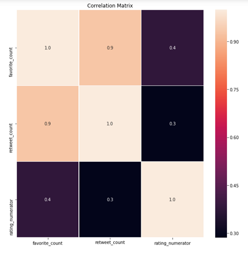

```python
ins = Image.open("Ins_4.PNG");
ins
```

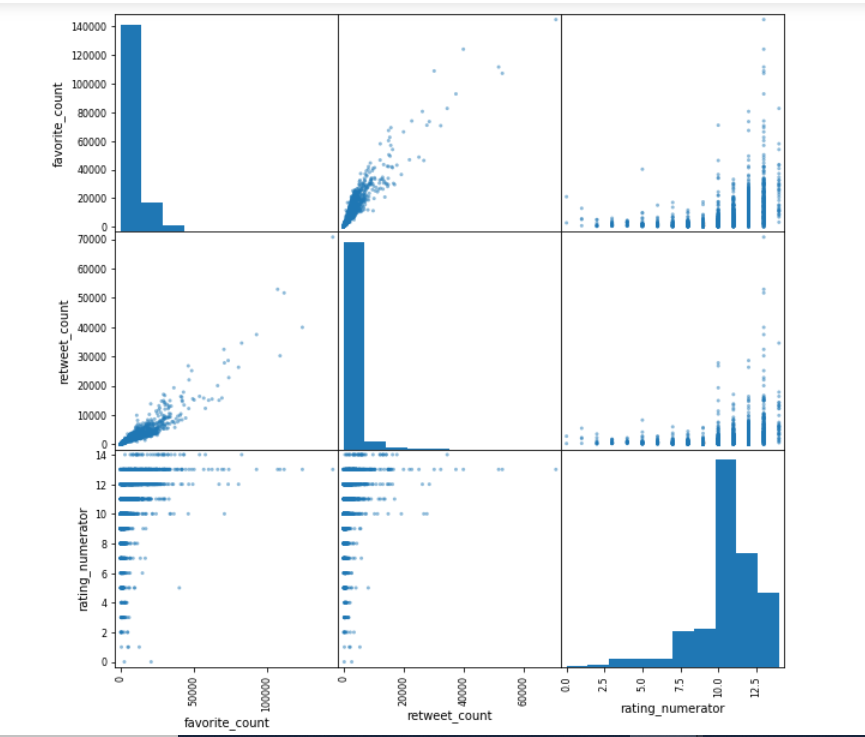

```python
ins = Image.open("Ins_5.PNG");
ins
```

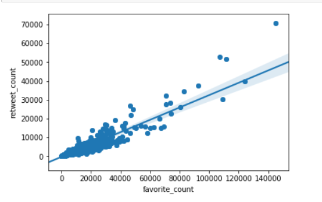

```python
ins = Image.open("Ins_6.PNG");
ins
```

It is important to note that even though the graphs suggest a very strong positive relationship between the two variables, there is actually no clear-cut evidence that one causes the other.

## Conclusion

This analysis was really enjoyable. In fact, analyzing such fascinating data gives me much hope that pursuing a career in data analysis is really worth it.  
I thoroughly enjoyed this project as it drove to me some uncomfortable zones; but I went through it all and I'm now proud to say I'm better skilled and equipped to take up a role as a data analyst.

Thanks to **ALX** and the **Udacity** team for this opportunity. Also, many thanks to Twitter (for granting me access to query the data). It wasn't a joke really. I applied for the keys as if I was applying to an MBA program. Lol 😃  
I also wish @WeRateDogs continued success and that many who were previously unaware of its efforts would now be more interested. Do well to check them out on Twitter and enjoy!.  
Thanks for reading.